## Formula 1: A Data Approach

Summer 2025 Data Science Project

Manvi Sharma, Shohini Sarkar, Lakshmee Harivanam Raghavendra

# Contributions

**Shohini:** (A, B, D, E) Proposed the project topic and wrote the Introduction, outlining the motivation behind predicting Formula 1 race outcomes using in-race metrics. She led the machine learning analysis, selecting and training models like Random Forest and Gradient Boosting. Rhea also summarized model performance using key evaluation metrics and helped identify which features were most influential in predicting final race position.

**Lakshmee:** (B, C, F, H) Responsible for producing all key visualizations tied to model performance and statistical methods, such as the correlation heatmap, boxplot of fastest lap speeds, and bar plots comparing models. She also handled the data citation and explanation, ensuring the datasets used were properly credited and their content clearly described for the reader. Her visual work played a central role in making complex results intuitive and easy to interpret.

**Manvi:** (C, F, G, H) Summarized the project in the “Insights and Conclusions” section, distilling all statistical and machine learning results into an accessible, well-organized summary that ties the entire project together. She also handled some of the exploratory data analysis and early statistical visualizations from previous checkpoints, helping shape the narrative of the project through both code and interpretation. Additionally, she created the Contributions section and ensured smooth coordination between team members to maintain a consistent tone and logical flow throughout the notebook.

# Introduction

Formula 1 is a sport where every second counts, and performance is shaped by a combination of driver skill, car engineering, and race-day strategy.

While final race positions are publicly availlable and celebrated, the underlying performance metrics that contribute to those outcomes are less often explored from a predictive standpoint. This project investigates the question:

**Can we predict a driver's final race position using in-race performance data such as fastest lap speed, lap rank, and total race time?**

Understanding the answer to this question holds significance for both racing teams and sports analysts.

By identifying which in-race metrics most strongly influence final results, teams can optimize their race strategies, allocate engineering resources effectively, and fine-tune driver performance. Additionally, this analysis contributes to the growing field of sports analytics, where data-driven models are increasingly being used to understand and improve competitive performance.

To address our question, we curated and explored historical Formula 1 race data, applying a range of statistical and machine learning methods. Specifically, we used correlation analysis to understand relationships between race metrics, outlier detection to examine variability in lap speeds, and hypothesis testing to compare performance across racing teams. In the primary analysis, we trained and evaluated multiple machine learning models to assess how well final race position could be predicted from key performance variables.

Our findings aim to provide both quantitative insights into Formula 1 race performance and practical implications for how data science can support strategic decision-making in competitive sports.

# Data Preprocessing

**Importing the data**

Available at this link: [F1 results data](https://www.kaggle.com/datasets/rohanrao/formula-1-world-championship-1950-2020/data?select=results.csv)

```python
# library imports
import pandas as pd
import numpy as np
import seaborn as sns
import matplotlib.pyplot as plt

# load the main results csv
results = pd.read_csv('results.csv')

# look at the dataset
display(results)
```

|  | resultId | raceId | driverId | constructorId | number | grid | position | positionText | positionOrder | points | laps | time | milliseconds | fastestLap | rank | fastestLapTime | fastestLapSpeed | statusId |
| --- | --- | --- | --- | --- | --- | --- | --- | --- | --- | --- | --- | --- | --- | --- | --- | --- | --- | --- |
| 0 | 1 | 18 | 1 | 1 | 22 | 1 | 1 | 1 | 1 | 10.0 | 58 | 1:34:50.616 | 5690616 | 39 | 2 | 1:27.452 | 218.300 | 1 |
| 1 | 2 | 18 | 2 | 2 | 3 | 5 | 2 | 2 | 2 | 8.0 | 58 | +5.478 | 5696094 | 41 | 3 | 1:27.739 | 217.586 | 1 |
| 2 | 3 | 18 | 3 | 3 | 7 | 7 | 3 | 3 | 3 | 6.0 | 58 | +8.163 | 5698779 | 41 | 5 | 1:28.090 | 216.719 | 1 |
| 3 | 4 | 18 | 4 | 4 | 5 | 11 | 4 | 4 | 4 | 5.0 | 58 | +17.181 | 5707797 | 58 | 7 | 1:28.603 | 215.464 | 1 |
| 4 | 5 | 18 | 5 | 1 | 23 | 3 | 5 | 5 | 5 | 4.0 | 58 | +18.014 | 5708630 | 43 | 1 | 1:27.418 | 218.385 | 1 |
| ... | ... | ... | ... | ... | ... | ... | ... | ... | ... | ... | ... | ... | ... | ... | ... | ... | ... | ... |
| 26754 | 26760 | 1144 | 825 | 210 | 20 | 14 | 16 | 16 | 16 | 0.0 | 57 | \N | \N | 57 | 1 | 1:25.637 | 222.002 | 11 |
| 26755 | 26761 | 1144 | 859 | 215 | 30 | 12 | 17 | 17 | 17 | 0.0 | 55 | \N | \N | 52 | 12 | 1:28.751 | 214.212 | 5 |
| 26756 | 26762 | 1144 | 822 | 15 | 77 | 9 | \N | R | 18 | 0.0 | 30 | \N | \N | 14 | 19 | 1:29.482 | 212.462 | 130 |
| 26757 | 26763 | 1144 | 861 | 3 | 43 | 20 | \N | R | 19 | 0.0 | 26 | \N | \N | 5 | 17 | 1:29.411 | 212.631 | 5 |
| 26758 | 26764 | 1144 | 815 | 9 | 11 | 10 | \N | R | 20 | 0.0 | 0 | \N | \N | \N | 0 | \N | \N | 4 |

26759 rows × 18 columns

**Parsing through the data**

```python
# check what datatypes all of the columns are

print(results.dtypes)
```

```
resultId             int64
raceId               int64
driverId             int64
constructorId        int64
number              object
grid                 int64
position            object
positionText        object
positionOrder        int64
points             float64
laps                 int64
time                object
milliseconds        object
fastestLap          object
rank                object
fastestLapTime      object
fastestLapSpeed     object
statusId             int64
dtype: object
```

```python
# convert the relevant types to numeric
convert_cols = ['position', 'milliseconds', 'fastestLap', 'rank', 'fastestLapSpeed']

for col in convert_cols:
    results[col] = pd.to_numeric(results[col], errors='coerce')

print(results.dtypes)
```

```
resultId             int64
raceId               int64
driverId             int64
constructorId        int64
number              object
grid                 int64
position           float64
positionText        object
positionOrder        int64
points             float64
laps                 int64
time                object
milliseconds       float64
fastestLap         float64
rank               float64
fastestLapTime      object
fastestLapSpeed    float64
statusId             int64
dtype: object
```

```python
# convert the fastest lap time variable to a timedelta format

def convert_to_secs(lap_time):
  try:
    minutes, seconds = lap_time.split(':')
    total_seconds = float(minutes) * 60 + float(seconds)
    return pd.to_timedelta(total_seconds, unit='s')
  except:
    return np.nan

results['fastestLapTime'] = results['fastestLapTime'].apply(convert_to_secs)
```

**Organizing the data**

Merging it with other relevant datasets

Driver data: [find it here](https://www.kaggle.com/datasets/rohanrao/formula-1-world-championship-1950-2020/data?select=drivers.csv)

Constructor (team) data: [find it here](https://www.kaggle.com/datasets/rohanrao/formula-1-world-championship-1950-2020/data?select=constructors.csv)

Race data: [find it here](https://www.kaggle.com/datasets/rohanrao/formula-1-world-championship-1950-2020/data?select=races.csv)

```python
# get the supporting csvs
drivers = pd.read_csv('drivers.csv')
constructors = pd.read_csv('constructors.csv')
races = pd.read_csv('races.csv')
```

```python
# make a copy of the initial results dataframe
merged = results.copy()

# merge with drivers csv
merged = merged.merge(drivers, on='driverId', how='left')

# merge with constructors csv
merged = merged.merge(constructors, on='constructorId', how='left')

# merge with races csv
merged = merged.merge(races[['raceId', 'year', 'name', 'circuitId']], on='raceId', how='left')


# get the drivers' names
merged['driverName'] = merged['forename'] + ' ' + merged['surname']
```

```python
# we get name_x and name_y because this is what pandas does when we merge two dataframes with the same column names

# select specific columns for analysis
selected_cols = [
    'raceId', 'year', 'name_y',
    'driverId', 'driverName',
    'constructorId', 'name_x',
    'grid', 'positionOrder', 'points',
    'positionText', 'statusId',
    'time', 'milliseconds',
    'fastestLap', 'rank', 'fastestLapTime', 'fastestLapSpeed'
]


# rename for clarity
merged = merged[selected_cols].rename(columns={
    'name_y': 'raceName',
    'name_x': 'constructorName'
})

display(merged)
```

|  | raceId | year | raceName | driverId | driverName | constructorId | constructorName | grid | positionOrder | points | positionText | statusId | time | milliseconds | fastestLap | rank | fastestLapTime | fastestLapSpeed |
| --- | --- | --- | --- | --- | --- | --- | --- | --- | --- | --- | --- | --- | --- | --- | --- | --- | --- | --- |
| 0 | 18 | 2008 | Australian Grand Prix | 1 | Lewis Hamilton | 1 | McLaren | 1 | 1 | 10.0 | 1 | 1 | 1:34:50.616 | 5690616.0 | 39.0 | 2.0 | 0 days 00:01:27.452000 | 218.300 |
| 1 | 18 | 2008 | Australian Grand Prix | 2 | Nick Heidfeld | 2 | BMW Sauber | 5 | 2 | 8.0 | 2 | 1 | +5.478 | 5696094.0 | 41.0 | 3.0 | 0 days 00:01:27.739000 | 217.586 |
| 2 | 18 | 2008 | Australian Grand Prix | 3 | Nico Rosberg | 3 | Williams | 7 | 3 | 6.0 | 3 | 1 | +8.163 | 5698779.0 | 41.0 | 5.0 | 0 days 00:01:28.090000 | 216.719 |
| 3 | 18 | 2008 | Australian Grand Prix | 4 | Fernando Alonso | 4 | Renault | 11 | 4 | 5.0 | 4 | 1 | +17.181 | 5707797.0 | 58.0 | 7.0 | 0 days 00:01:28.603000 | 215.464 |
| 4 | 18 | 2008 | Australian Grand Prix | 5 | Heikki Kovalainen | 1 | McLaren | 3 | 5 | 4.0 | 5 | 1 | +18.014 | 5708630.0 | 43.0 | 1.0 | 0 days 00:01:27.418000 | 218.385 |
| ... | ... | ... | ... | ... | ... | ... | ... | ... | ... | ... | ... | ... | ... | ... | ... | ... | ... | ... |
| 26754 | 1144 | 2024 | Abu Dhabi Grand Prix | 825 | Kevin Magnussen | 210 | Haas F1 Team | 14 | 16 | 0.0 | 16 | 11 | \N | NaN | 57.0 | 1.0 | 0 days 00:01:25.637000 | 222.002 |
| 26755 | 1144 | 2024 | Abu Dhabi Grand Prix | 859 | Liam Lawson | 215 | RB F1 Team | 12 | 17 | 0.0 | 17 | 5 | \N | NaN | 52.0 | 12.0 | 0 days 00:01:28.751000 | 214.212 |
| 26756 | 1144 | 2024 | Abu Dhabi Grand Prix | 822 | Valtteri Bottas | 15 | Sauber | 9 | 18 | 0.0 | R | 130 | \N | NaN | 14.0 | 19.0 | 0 days 00:01:29.482000 | 212.462 |
| 26757 | 1144 | 2024 | Abu Dhabi Grand Prix | 861 | Franco Colapinto | 3 | Williams | 20 | 19 | 0.0 | R | 5 | \N | NaN | 5.0 | 17.0 | 0 days 00:01:29.411000 | 212.631 |
| 26758 | 1144 | 2024 | Abu Dhabi Grand Prix | 815 | Sergio Pérez | 9 | Red Bull | 10 | 20 | 0.0 | R | 4 | \N | NaN | NaN | 0.0 | NaT | NaN |

26759 rows × 18 columns

**Statistical Method # 1**

Methodology: Using Pearson Correlation (Explored in class) to determine strength of relationship between variables

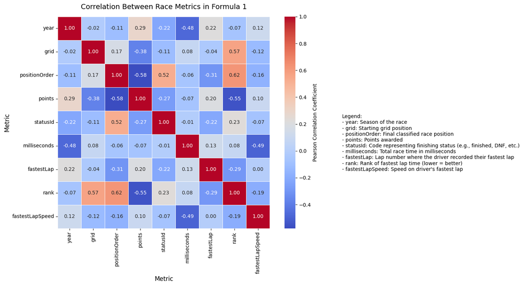

```python
# keep only numeric columns for correlation
numeric_df = merged.select_dtypes(include=['float64', 'int64'])

# filter out ID columns
numeric_df = numeric_df.drop(columns=['raceId', 'driverId', 'constructorId'])

# get the correlation matrix
corr_matrix = numeric_df.corr()

# plot a correlation heatmap
plt.figure(figsize=(10, 8))
heatmap = sns.heatmap(
    corr_matrix,
    annot=True,
    fmt=".2f",
    cmap="coolwarm",
    square=True,
    linewidths=0.5,
    cbar_kws={'label': 'Pearson Correlation Coefficient'}
)


plt.title("Correlation Between Race Metrics in Formula 1", fontsize=14, pad=15)
plt.xlabel("Metric", fontsize=12)
plt.ylabel("Metric", fontsize=12)

# create a legend
legend_text = """
Legend:
- year: Season of the race
- grid: Starting grid position
- positionOrder: Final classified race position
- points: Points awarded
- statusId: Code representing finishing status (e.g., finished, DNF, etc.)
- milliseconds: Total race time in milliseconds
- fastestLap: Lap number where the driver recorded their fastest lap
- rank: Rank of fastest lap time (lower = better)
- fastestLapSpeed: Speed on driver's fastest lap
"""

plt.gcf().text(1.02, 0.5, legend_text, fontsize=10, va='center')
plt.tight_layout()
plt.show()
```

positionOrder and points were strongly negatively correlated (r = -0.58), indicating that drivers who finish in better positions earn more points which is expected

rank and points also showed a strong negative correlation (r = -0.55), suggesting that drivers who rank better for fastest lap times tend to score more points

Conversely, positionOrder and rank had a strong positive correlation (r = 0.62), confirming that race performance and lap speed go hand-in-hand

**Statistical Method # 2**

Box plot to explore outliers in fastest lap speeds

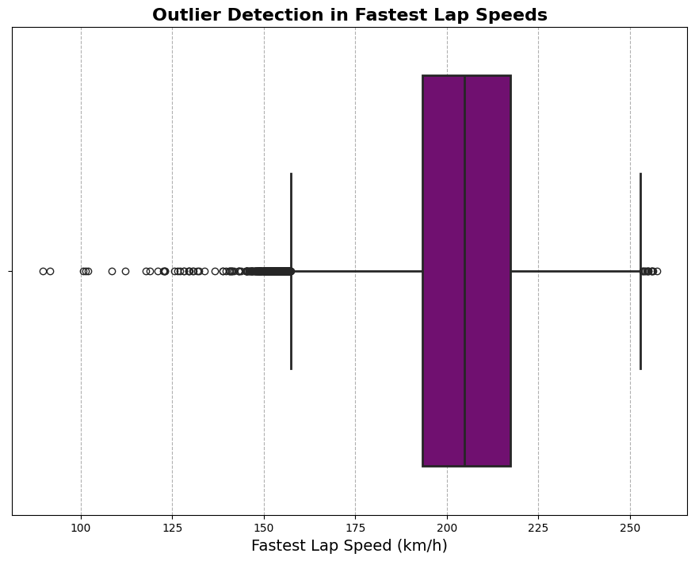

```python
plt.figure(figsize=(11, 8))

# create boxplot with fastest lap speeds (to find any outliers)
sns.boxplot(x=merged['fastestLapSpeed'], color='purple', linewidth=2)

# axis title + labels
plt.title("Outlier Detection in Fastest Lap Speeds", fontsize=16, fontweight='bold')
plt.xlabel("Fastest Lap Speed (km/h)", fontsize=14)

# gridlines
plt.grid(axis='x', linestyle='--')

plt.show()
```

This boxplot shows the distribution of Fastest Lap Speeds (km/h) in the Formula 1 dataset and helps point out any outliers. The purple box in the middle is the interquartile range (IQR), which covers the middle 50% of all the fastest lap speeds recorded. The bottom of the box is the 25th percentile (Q1), and the top is the 75th percentile (Q3). The line within the box is the median (50th percentile). For this dataset, it shows that the median fastest lap speed is around 205 km/h, meaning half of the drivers recorded fastest laps above this speed and half below.

The whiskers demonstrate where the normal lap speeds end. Any dots outside of those whiskers are considered to be the outliers (certain speeds that highly differ from what is considered normal). There are many outliers on both sides.

On the left side, some fastest lap speeds are much below 150 km/h, which is unusually slow. A few speeds even drop under 100 km/h, which is significantly slow. This suggests there could have been issues like a crash, mechanical failure, or poor track conditions causing these low speeds as indicated by the statusId column. We can confirm exactly what caused this by further examining the statusIds for these outliers.

On the right side, there are not as many outliers, but we see lap speeds over 250 km/h. This is very fast. This could likely be related to improvements in car technology as the years progress, constructorName (teams like Red Bull, McLaren, or Mercedes are known for making high end cars which make these competitive), or race conditions (some may have more straighter track sections).

Overall, this graph shows that fastest lap speeds are generally between about 190 km/h and 220 km/h. However, we see outliers when considering different years, teams, and races which could be due to advancements in manufacturing, mechnical issues, and varied race conditions.

**Statistical Method # 3**

Hypothesis test on average lap speed: team A vs team B

This cell uses status data: [find it here](https://www.kaggle.com/datasets/rohanrao/formula-1-world-championship-1950-2020/data?select=status.csv)

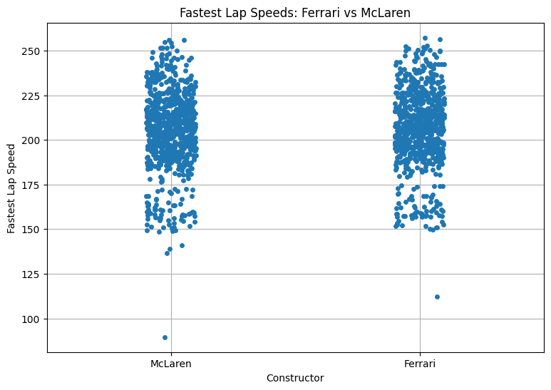

```python
import pandas as pd
status = pd.read_csv("status.csv")




results = results.merge(status, on="statusId", how="left")

# add constructor (team) names
results = results.merge(constructors[["constructorId", "name"]], on="constructorId", how="left")
results.rename(columns={"name": "constructor_name"}, inplace=True)



# drop rows with missing fastestLapSpeed or team
results_clean = results.dropna(subset=["fastestLapSpeed", "constructor_name"])

# pick 2 teams with most data
team_counts = results_clean["constructor_name"].value_counts()
team_a, team_b = team_counts.index[:2]

# get lap speeds for each team
laps_a = results_clean[results_clean["constructor_name"] == team_a]["fastestLapSpeed"]
laps_b = results_clean[results_clean["constructor_name"] == team_b]["fastestLapSpeed"]

# run Welch's t-test
from scipy.stats import ttest_ind
t_stat, p_val = ttest_ind(laps_a, laps_b, equal_var=False)





#Confirm
#if p_val < 0.05:
#    print("significant → reject null hypothesis")
#else:
#    print("not significant")



# plot the results using the strip plot

import seaborn as sns
import matplotlib.pyplot as plt




subset = results_clean[results_clean["constructor_name"].isin([team_a, team_b])]

plt.figure(figsize=(9, 6))
sns.stripplot(x="constructor_name", y="fastestLapSpeed", data=subset, jitter=True)




plt.title(f"Fastest Lap Speeds: {team_a} vs {team_b}")
plt.xlabel("Constructor")
plt.ylabel("Fastest Lap Speed")
plt.grid(True)
plt.show()
```

- Welch’s t-test comparing fastest lap speeds between Ferrari and McLaren

For this method, I wanted to see if two of the top F1 teams — Ferrari and McLaren — had significantly different average fastest lap speeds. I used a Welch’s t-test, which is a version of the t-test that works even if the two groups have different variances or sample sizes (which is usually the case in F1 race data).

The strip plot above also backs this up — both teams have a pretty similar spread of lap speeds with a lot of overlap. There are no clear gaps or shifts that would suggest one team is consistently faster.

# **Machine Learning Approach**

Although our initial correlation matrix highlighted a few key metrics, other variables such as starting grid position, year of the race, or finishing status may also contribute predictive value. By starting with a broad set of features including those identified by the correlation matrix and using feature importance, we can identify which variables most strongly influence the driver's final race position.

# Machine Learning Pipeline

Our machine learning process involves the following stages:

**Feature Selection & Preparation:**

Start with all relevant numeric race features (e.g., grid position, milliseconds, fastest lap number, lap rank, fastest lap speed, year, etc.).

**Initial Model Training:**

Train a Random Forest model on the full set of features.

Use the model’s feature importance scores to identify the top 5–7 most predictive features.

This step helps narrow down our final feature set to the most impactful variables.

**Model Exploration:**

Train and compare several regression models using the selected top features:

Linear Regression

Random Forest Regression

Gradient Boosting Regression

Support Vector Regression

**Training and Testing:**

Split the data into training and testing sets.

Evaluate initial performance using standard metrics.

**Hyperparameter Tuning:**

For the top-performing models, apply GridSearchCV to fine-tune hyperparameters.

Ensure models are well-optimized to balance performance and generalization.

**Model Evaluation:**

Compare models using:

Mean Absolute Error (MAE)

Root Mean Squared Error (RMSE)

R² Score

Start by importing necessary libraries

```python
# import libraries
from scipy.stats import pearsonr
from sklearn.model_selection import train_test_split, GridSearchCV
from sklearn.ensemble import RandomForestRegressor, GradientBoostingRegressor
from sklearn.linear_model import LinearRegression
from sklearn.svm import SVR
from sklearn.metrics import mean_absolute_error, mean_squared_error, r2_score
```

Next we identify our features and target in the data and initialize a basic Random Forest model for determining feature importance

```
Top features selected: ['grid', 'rank', 'milliseconds', 'fastestLapTime', 'fastestLapSpeed', 'fastestLap', 'laps']
```

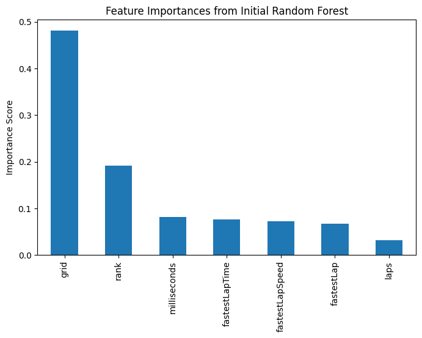

```python
# Feature Selection & Preparation

# identify the numeric columns
# convert fastestLapTime timedelta to total seconds so it's usable by the model
results['fastestLapTime'] = results['fastestLapTime'].dt.total_seconds()
numeric_cols = results.select_dtypes(include=np.number).columns.tolist()

# don't include id features
id_cols = ['raceId', 'driverId', 'constructorId', 'statusId', 'resultId', 'lapId']
numeric_cols = [col for col in numeric_cols if col not in id_cols]

# drop rows that have missing values
data = results[numeric_cols].dropna()


# identify the target as the final position and the features as the rest of the numeric data
# drop the target and confounding features
X = data.drop(columns=['position', 'positionOrder', 'points'])
y = data['position']

# use a basic random forest model for feature importance
rf = RandomForestRegressor(random_state=42)
rf.fit(X, y)

# get feature importances
feature_importances = pd.Series(rf.feature_importances_, index=X.columns).sort_values(ascending=False)
top_features = feature_importances.head(7).index.tolist()

print("Top features selected:", top_features)

plt.figure(figsize=(8, 5))
feature_importances.head(7).plot(kind='bar')
plt.title('Feature Importances from Initial Random Forest')
plt.ylabel('Importance Score')
plt.show()
```

The top features identified were:

grid: The driver’s starting grid position, which unsurprisingly had the strongest influence on final race position.

rank: The driver’s rank for their fastest lap, showing lap performance plays a significant role.

milliseconds and fastestLapTime: Indicators of overall race speed and fastest lap time, further emphasizing the importance of race pace.

fastestLapSpeed, fastestLap, and laps: Additional race metrics capturing lap-specific performance and race characteristics.

( fastestLapTime is the actual time duration of the driver’s fastest lap, fastestLapSpeed is the average speed (km/h) during the fastest lap, and fastestLap is the lap number when the driver recorded their fastest lap. )

These results confirm that both starting position and in-race performance metrics are important predictors of final position, justifying their inclusion in our machine learning models.

```python
# define the final feature set with the top performing features
X_final = data[top_features]

# train-test split the data
from sklearn.model_selection import train_test_split

X_train, X_test, y_train, y_test = train_test_split(X_final, y, test_size=0.2, random_state=42)

# initialize relevant models
from sklearn.linear_model import LinearRegression
from sklearn.ensemble import RandomForestRegressor, GradientBoostingRegressor
from sklearn.svm import SVR

models = {
    'Linear Regression': LinearRegression(),
    'Random Forest': RandomForestRegressor(random_state=42),
    'Gradient Boosting': GradientBoostingRegressor(random_state=42),
    'Support Vector Regression': SVR()
}

# train and evaluate models
from sklearn.metrics import mean_absolute_error, mean_squared_error, r2_score

for name, model in models.items():
    model.fit(X_train, y_train)
    y_pred = model.predict(X_test)

    print(f"\n{name} Model")
    print(f"MAE: {mean_absolute_error(y_test, y_pred):.2f}")
    print(f"RMSE: {mean_squared_error(y_test, y_pred) ** 0.5:.2f}")
    print(f"R² Score: {r2_score(y_test, y_pred):.3f}")
```

```
Linear Regression Model
MAE: 1.94
RMSE: 2.61
R² Score: 0.574

Random Forest Model
MAE: 1.95
RMSE: 2.61
R² Score: 0.574

Gradient Boosting Model
MAE: 1.87
RMSE: 2.50
R² Score: 0.607

Support Vector Regression Model
MAE: 3.29
RMSE: 3.99
R² Score: 0.006
```

Hyperparameter Tuning

Performing hyperparameter for the top performing models (Random Forest, Gradient Boosting)

```python
# Hyperparameter tuning for Gradient Boosting Model

from sklearn.model_selection import GridSearchCV

# gradient boosting model hyperparameters
gb_params = {
    'n_estimators': [100, 200],
    'learning_rate': [0.05, 0.1, 0.2],
    'max_depth': [3, 5, 7],
    'min_samples_split': [2, 5],
}

gb_grid = GridSearchCV(
    GradientBoostingRegressor(random_state=42),
    gb_params,
    cv=3,
    scoring='neg_mean_squared_error',
    n_jobs=-1
)

gb_grid.fit(X_train, y_train)

# best gradient boosting model
best_gb = gb_grid.best_estimator_

# evaluate tuned gradient boosting
y_pred_gb = best_gb.predict(X_test)

print("\n--- Tuned Gradient Boosting ---")
print(f"Best Params: {gb_grid.best_params_}")
print(f"MAE: {mean_absolute_error(y_test, y_pred_gb):.2f}")
print(f"RMSE: {mean_squared_error(y_test, y_pred_gb) ** 0.5:.2f}")
print(f"R² Score: {r2_score(y_test, y_pred_gb):.3f}")
```

```
--- Tuned Gradient Boosting ---
Best Params: {'learning_rate': 0.05, 'max_depth': 5, 'min_samples_split': 5, 'n_estimators': 200}
MAE: 1.87
RMSE: 2.51
R² Score: 0.607
```

```python
# random forest hyperparameters
rf_params = {
    'n_estimators': [100, 200, 400],
    'max_depth': [None, 10, 20],
    'min_samples_split': [2, 5, 10, 15],
}

rf_grid = GridSearchCV(
    RandomForestRegressor(random_state=42),
    rf_params,
    cv=3,
    scoring='neg_mean_squared_error',
    n_jobs=-1
)

rf_grid.fit(X_train, y_train)

# best random forest model
best_rf = rf_grid.best_estimator_

# evaluate tuned Random Forest
y_pred_rf = best_rf.predict(X_test)

print("\n--- Tuned Random Forest ---")
print(f"Best Params: {rf_grid.best_params_}")
print(f"MAE: {mean_absolute_error(y_test, y_pred_rf):.2f}")
print(f"RMSE: {mean_squared_error(y_test, y_pred_rf) ** 0.5:.2f}")
print(f"R² Score: {r2_score(y_test, y_pred_rf):.3f}")
```

```
--- Tuned Random Forest ---
Best Params: {'max_depth': 10, 'min_samples_split': 15, 'n_estimators': 200}
MAE: 1.91
RMSE: 2.56
R² Score: 0.591
```

After training and comparing several machine learning models, we found that ensemble models worked best for predicting a driver’s final race position.

The Gradient Boosting Regressor gave the strongest performance overall, with an R² score around 0.6. This means it was able to explain about 61% of the variation in final race position, which is pretty solid given how unpredictable racing can be. Its MAE and RMSE were also the lowest out of all the models, showing that it consistently made more accurate predictions compared to the others.

Linear Regression, which we used as a baseline, gave an R² of about 0.57. So, it did capture some of the patterns between features like fastest lap speed and race position, but clearly didn’t handle the complexity of the data as well as the ensemble models.

Support Vector Regression (SVR) didn’t perform well at all — it barely explained any variation in the final positions (R² around 0.006). This likely happened because SVR is very sensitive to hyperparameters and feature scaling, and in this case, the default settings weren’t a good match for our dataset. Because of this, we didn’t bother tuning it further.

In summary, the results show that features like fastest lap time, lap rank, race time, and starting grid position definitely help explain race outcomes, but they don’t tell the whole story. Race strategy, pit stops, weather conditions, and incidents like crashes are also huge factors, but they aren’t captured in this dataset. Still, it’s clear that a well-tuned ensemble model like Gradient Boosting can provide a meaningful predictive baseline for understanding Formula 1 race results.

# **Visualizations based on ML results**

## Bar plot to show Feature Importance:

We will determine which performance metrics mattered most in predicting a driver's final race position

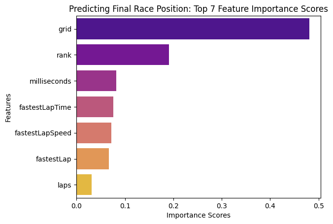

```python
# our ML approach uses model’s feature importance scores to identify the top 5–7 most predictive features so we are displaying 7 of them here

top_7_features = feature_importances.head(7)

importance_scores = top_7_features.values
feature_names = top_7_features.index

sns.barplot(x= importance_scores, y = feature_names, hue = feature_names, palette='plasma')


plt.title('Predicting Final Race Position: Top 7 Feature Importance Scores')
plt.xlabel('Importance Scores')
plt.ylabel('Features')

plt.show()
```

Discussion of visual:

Grid (the racer's starting position) was the most important feature. This indicates that where a driver starts the race has a very strong influence on where they finish. This ultimately means that starting near the front can offer a cleaner path and fewer obstacles for the racer, leading to better outcomes.

## Bar plot to show different model performances:

We will determine which model performed the best based on R squared scores and mean absolute error

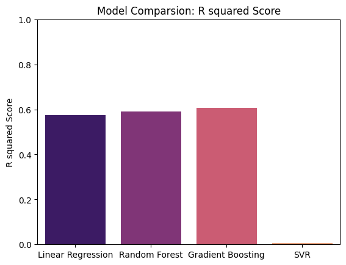

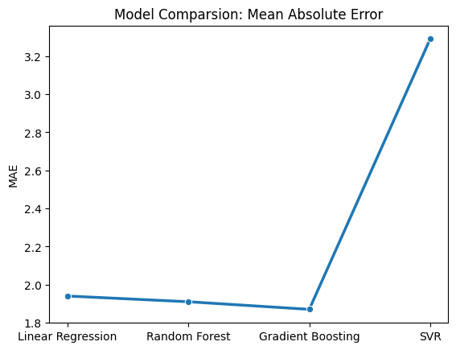

```python
# these are all the models we used in our ML approach above
ML_model_names = ['Linear Regression', 'Random Forest', 'Gradient Boosting', 'SVR']

# these were our r2 coeff scores
r2_scores = [0.574, 0.591, 0.607, 0.006]

# these were our MAE scores
mean_abs_error_scores = [1.94, 1.91, 1.87, 3.29]

# bar plot for visualizing our r sq scores
sns.barplot( x = ML_model_names, y = r2_scores, hue = ML_model_names, palette='magma')

plt.title('Model Comparsion: R squared Score')
plt.ylabel('R squared Score')
plt.ylim(0, 1)
plt.show()

# line plot for our MAE scores
sns.lineplot(x = ML_model_names, y= mean_abs_error_scores, marker='o', linewidth=2.5)

plt.title('Model Comparsion: Mean Absolute Error')
plt.ylabel('MAE')
plt.show()
```

Discussion of visual:

Gradient Boosting had the highest R squared score (0.607) and the lowest MAE (1.87). This means it was the most accurate and consistent model overall. It was able to explain the most variation in race outcomes while minimizing the average prediction error.

On the flipside, Support Vector Regression (SVR) performed the worst across both metrics, with almost no explanatory power from R squared score equaling close to and the highest MAE at around 3.29. This indicates large and frequent prediction errors. This suggests SVR is not suitable for this task without lots of tuning

## Scatter plot to compare actual vs predicted race positions for the tuned Gradient Boosting model:

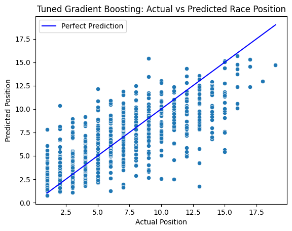

```python
# from previous plot we see that the gradient boosting performed the best
# here, we will compare actual vs predicted race positions for the tuned Gradient Boosting model through visuals

# x = our actual values from test data
# y = what the model's prediction was
sns.scatterplot(x=y_test, y=y_pred_gb)

# will add a line to represent a perfect prediction (where our model prediction matches what the actual test values were)

# find min and max our from the actual test data (y_test)
x_start = min(y_test)
x_end = max(y_test)

# same values for y (we want to form the prediction line)
y_start = x_start
y_end = x_end

# solid blue line for showing pref pred
plt.plot([x_start, x_end], [y_start, y_end], '-b', label='Perfect Prediction')

plt.title('Tuned Gradient Boosting: Actual vs Predicted Race Position')
plt.xlabel('Actual Position')
plt.ylabel('Predicted Position')

plt.legend()
plt.show()
```

Discussion of visual:

From the previous visuals, we have determined that Tuned Gradient Booting works best.

From the scatter plot here, we see that most points cluster near the blue Perfect Prediction line, especially for drivers who finished between positions 1 and 10. This shows that the model performed particularly well at predicting front-to-mid of the pack.

As we move to higher actual positions (like 15-20), the predicted values become more spread out. This wider range of prediction errors is somewhat expected because the lower ranks can often be caused by unpredictable events like mechanical failures.

## Histogram to show residual error:

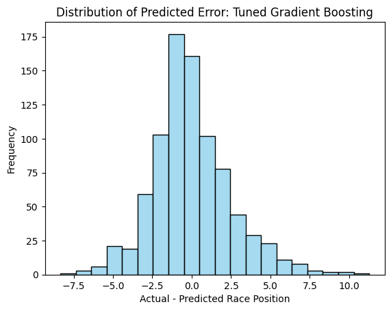

```python
# the difference in what the actual was vs what our model predicted
residual_errors = y_test - y_pred_gb

sns.histplot(residual_errors, bins=20, color='skyblue')

plt.title("Distribution of Predicted Error: Tuned Gradient Boosting")
plt.xlabel("Actual - Predicted Race Position")
plt.ylabel("Frequency")

plt.show()
```

Discussion of visual:

With the histogram, we are able to see that most prediction errors fall within + or - 2 positions. This means that the model typically predicts a driver’s finish within just 1 or 2 spots of their actual result. This is a nice accuracy level.

The distribution is centered near 0 and pretty symmetrical. This means that the model is not consistently over/under predicting any ranks. There are a few larger errors (+/- 7) but they are relatively not too frequent.

Overall, the histogram indicates that the model is making consistent predictions across most of the races

# Final Insights and Conclusions

In this project, we conducted an in-depth exploration into predicting Formula 1 drivers' final race positions based on various in-race performance metrics. Our analysis combined rigorous statistical methods with advanced machine learning techniques, providing both accurate predictive capabilities and meaningful insights into race dynamics.

In our machine learning analysis, we tested several models including Linear Regression, Random Forest, Gradient Boosting, and Support Vector Regression. Gradient Boosting stood out as the most accurate, achieving an R² score of about 0.607. This means it explained over 60% of the variability in race outcomes, accurately predicting drivers' finishing positions typically within just 1–2 spots. Additionally, our error analysis showed that mistakes made by this model were generally small, evenly distributed, and unbiased.

This project highlights a well-rounded data science approach, combining solid statistical analysis with reliable predictive modeling. We thoughtfully integrated multiple data sources, confirmed key relationships through correlation and significance testing, and fine-tuned our models to ensure the results were not only accurate but also meaningful and applicable beyond just our dataset.

Overall, our project successfully identified key factors influencing Formula 1 race outcomes, demonstrating the strength of data-driven methods in revealing meaningful patterns, even in dynamic, complex environments like motorsports. These insights can significantly enhance strategic decision-making and deepen understanding of Formula 1 dynamics for both professionals in the field and anyone interested in the sport.

# Sources Cited + Explained

The data we used for this project came from publicly available Formula 1 datasets which were hosted on Kaggle.

Source: [F1 results data](https://www.kaggle.com/datasets/rohanrao/formula-1-world-championship-1950-2020/data?select=results.csv)

The main files included:

results.csv: Contains each driver's position, points, lap times, and fastest lap info

drivers.csv: Driver details like name and nationality

constructors.csv: Information about the teams (like Mercedes, Red Bull)

races.csv: Race-specific details like the year and name of the race

status.csv: Reasons why drivers did not finish(mechanical issues, accident, illness)

These datasets allowed us to merge important performance metrics with driver/team identities and the context of races over the time period of 1950 to 2024.